# Using the R package **gdm** to analyze and map biodiversity patterns

Matt Fitzpatrick & Matthew Lisk

September 9, 2015

# Introduction

The R package **gdm** implements Generalized Dissimilarity Modeling (Ferrier S et al. 2007) to analyze and map spatial patterns of biodiversity. GDM models biological variation as a function of environment and geography using distance matrices – specifically by relating dissimilarity in species composition (or any biological distance, notably genetic (Fitzpatrick and Keller 2015), phylogenetic (Rosauer et al. 2014), or function/trait differences (Thomassen et al. 2010)) between sites to how much sites differ in their environmental conditions (environmental distance) and how isolated they are from one another (geographical distance). Geographical distance measures can be simple Euclidean separation or more complex measures of isolation, such as least cost paths or resistance distance. See (Ferrier S et al. 2007) for strategies for including categorical variables. This vignette demonstrates how to implement and interpret generalized dissimilarity models in the context of analyzing and mapping species-level patterns. Examples for modeling genetic variation within species will be included in a future update, though the techniques are largely identical to the species-level case (only the input biological data differ and the interpretations of variation in species vs. genetic composition).

# gdm Basics

The **gdm** package is available on CRAN, development versions are available on GitHub. This vignette covers only those functions currently available from the CRAN version.

```r
# installation of the package from CRAN
#install.packages("gdm")

# installation from GitHub
#library(devtools)
#install_github("fitzLab-AL/GDM")

library(gdm)
```

## Example Data

The biological data provided in the **gdm** package are occurrence data for plants from southwest Australia (Fitzpatrick et al. 2013). Of the original data, a subset of 26 species were selected to be included with the package. The full datasets are available from [Dryad](http://datadryad.org/resource/doi:10.5061/dryad.81p60). The environmental data include both climatic and soils variables, with the climate data being supplied as both tabular (at sites only) and raster formats (all of southwest Australia).

GDM can use several data formats as input. Most common are site-by-species tables (sites in rows, species across columns) for the response and site-by-environment tables (sites in rows, predictors across columns) as the predictors, though distance matrices and rasters are also accommodated. For example purposes, a biological dissimilarity matrix is provided to showcase the use of a pre-formatted distance matrix (table type 3) as the response variable, though note that distance matrices can also be used as predictors (e.g., to model compositional variation in one group as a function of compositional variation in another group, (Jones et al. 2013)).

The first example uses an x-y species list where there is one row *per species record rather than per site* - similar to what would be obtained from online databases such as GBIF. Note that the rows and their order must match in the biological and environmental data frames and must not include NAs. In this example both the species and environmental data are provided in the same table, which are then indexed to create two tables, one for the species data and the other for the environmental data.

```r
# reads in example input data
load(system.file("./data/gdm.RData", package="gdm"))
# columns 3-7 are soils variables, remainder are climate
gdmExpData[1:3,]
```

```
##   species site    awcA  phTotal   sandA    shcA solumDepth     bio5
## 1    spp1 1066 14.4725 546.1800 71.3250 178.865   875.1725 31.43824
## 2    spp1 1026 16.2575 470.9950 68.8975 105.840   928.4925 33.14412
## 3    spp1 1025 23.1375 459.7425 71.4700  88.355   892.2275 32.84000
##       bio6    bio15 bio18    bio19       Lat     Long
## 1 5.058823 40.38235     0 132.6471 -32.99425 118.7573
## 2 4.852941 48.20588     0 140.2941 -32.04285 118.3495
## 3 4.817143 53.88571    43 145.0571 -31.99067 117.8260
```

```r
# get columns with xy, site ID, and species data
sppTab <- gdmExpData[, c("species", "site", "Lat", "Long")]

# get columns with env. data and xy-coordinates
envTab <- gdmExpData[, c(2:ncol(gdmExpData))]
```

## Preparing site-pair tables

The initial step in fitting a generalized dissimilarity model is to combine the biological and environmental data into “site-pair” format. This can be accomplished using the `formatsitepair` function. Each row in the resulting site-pair table contains a biological distance measure in the first column (the default is Bray-Curtis distance though any measure scaled between 0-1 will work). The second column contains the weight to be assigned to each data point in model fitting (defaults to 1, but can be customized by the user or can be scaled to site richness, see below). The remaining columns are the environmental values at a site (s1) and those at a second site (s2) making up a site pair. Subsequent rows repeat this pattern until all possible site pairs are represented and such that pairwise distances between all sites can be calculated and used as predictors. While the site-pair table format can produce extremely large data frames and contain numerous repeat values, it also allows great flexibility. Most notably, individual site pairs easily can be excluded from model fitting.

A properly formatted site-pair table will have at least six columns (distance, weights, s1.xCoord, s1.yCoord, s2.xCoord, s2.yCoord) and possibly more depending upon how many predictor variables are included. See `?formatsitepair` and `?gdm` for more details.

```r
# x-y species list example
gdmTab <- formatsitepair(sppTab, bioFormat=2, XColumn="Long", YColumn="Lat",
                         sppColumn="species", siteColumn="site", predData=envTab)
gdmTab[1:3,]
```

```
##      distance weights s1.xCoord s1.yCoord s2.xCoord s2.yCoord s1.awcA
## 1   0.4485981       1   115.057 -29.40472  115.5677 -29.46599 23.0101
## 1.1 0.7575758       1   115.057 -29.40472  116.0789 -29.52556 23.0101
## 1.2 0.8939394       1   115.057 -29.40472  116.5907 -29.58342 23.0101
##     s1.phTotal s1.sandA  s1.shcA s1.solumDepth s1.bio5 s1.bio6 s1.bio15
## 1     480.3266 83.99326 477.5656      1129.933  34.668   8.908    86.64
## 1.1   480.3266 83.99326 477.5656      1129.933  34.668   8.908    86.64
## 1.2   480.3266 83.99326 477.5656      1129.933  34.668   8.908    86.64
##     s1.bio18 s1.bio19 s2.awcA s2.phTotal s2.sandA  s2.shcA s2.solumDepth
## 1          0   267.44 22.3925   494.1225  76.6900 357.7225     1183.9025
## 1.1        0   267.44 17.0975   415.1275  70.0175 112.4800      985.5300
## 1.2        0   267.44 17.0300   333.4400  71.5950 165.7250      956.5425
##      s2.bio5  s2.bio6 s2.bio15 s2.bio18 s2.bio19
## 1   35.50571 7.448572 75.37143        0 228.6572
## 1.1 36.05000 6.605882 64.52941        0 168.8824
## 1.2 36.18750 6.131250 58.75000        0 141.1250
```

```r
# Biological distance matrix example
dim(gdmDissim)
```

```
## [1] 94 94
```

```r
gdmDissim[1:5, 1:5]
```

```
##          V1        V2        V3        V4        V5
## 1 0.0000000 0.8181818 1.0000000 0.5000000 0.7500000
## 2 0.8181818 0.0000000 0.9000000 0.7777778 0.6551724
## 3 1.0000000 0.9000000 0.0000000 1.0000000 0.5757576
## 4 0.5000000 0.7777778 1.0000000 0.0000000 0.9090909
## 5 0.7500000 0.6551724 0.5757576 0.9090909 0.0000000
```

```r
gdmTab.dis <- formatsitepair(gdmDissim, bioFormat=3, XColumn="Long", YColumn="Lat",
                            predData=envTab, siteColumn="site")
```

Environmental data can be extracted directly from rasters, assuming x-y coordinates of sites are provided in either a site-species table (table type 1) or as a x-y species list (table type 2). The `formatsitepair` function assumes that the coordinates of the sites are in the same coordinate system as the raster layers.

```r
# environmental raster data
rastFile <- system.file("./extdata/stackedVars.grd", package="gdm")
envRast <- stack(rastFile)

gdmTab.rast <- formatsitepair(sppTab, bioFormat=2, XColumn="Long", YColumn="Lat",
                             sppColumn="species", siteColumn="site", predData=envRast)

# make sure there are no NA values
# e.g., if some sites do not intersect the rasters
sum(is.na(gdmTab.rast))
```

```
## [1] 465
```

```r
gdmTab.rast <- na.omit(gdmTab.rast)
```

## Dealing with biases associated with presence-only data

The ideal biological data for fitting a GDM are occurrence records (presence-absence or abundance) from a network of sites where all species (from one or more taxonomic groups) have been intensively sampled such that compositional dissimilarity can be reliably estimated between sites. However most species data are collected as part of ad hoc surveys and are presence-only. Under these circumstances, there is no systematic surveying and no sites per se, but rather grid cells with some number of occurrence records depending on the number of species observed, with many grid cells having none, a few, or even a single species record. When under-sampled sites are used to calculate compositional dissimilarity, erroneously high values will result, which will bias the model.

The `formatsitepair` function provides a few options for dealing with this potential bias, including (i) weighting sites relative to the number of species observed (`weightType="richness"`), (ii) removing sites with few species (e.g., `speciesFilter=10`) or (iii) both. Decisions regarding which approach to use will depend on the nature of the data and study system. See (Ferrier S et al. 2007) for further discussion.

```r
# weight by site richness
gdmTab.rw <- formatsitepair(sppTab, bioFormat=2, XColumn="Long", YColumn="Lat",
                         sppColumn="species", siteColumn="site",
                         predData=envTab, weightType="richness")

# weights based on richness (number of species records)
gdmTab.rw$weights[1:5]
```

```
## [1] 0.20167224 0.14515050 0.11538462 0.13879599 0.08361204
```

```r
# remove sites with < 10 species records
gdmTab.sf <- formatsitepair(sppTab, bioFormat=2, XColumn="Long", YColumn="Lat",
                         sppColumn="species", siteColumn="site",
                         predData=envTab, sppFilter=10)
```

# **gdm** analysis

GDM is a nonlinear extension of permutational matrix regression that uses flexible splines and a GLM to accommodate two types of nonlinearity common in ecological datasets: (1) variation in the rate of compositional turnover (non-stationarity) along environmental gradients, and (2) the curvilinear relationship between biological distance and environmental and geographical distance.

The function `gdm` fits generalized dissimilarity models and is simple to use once the biological and predictor data have been formatted to a site-pair table. In addition to specifying whether or not the model should be fit with geographical distance as a predictor variable, the user can also specify (i) the number of I-spline basis functions (the default is three, with larger values producing more complex splines) and (ii) the locations of “knots” along the splines (defaults 0 (minimum), 50 (median), and 100 (maximum) quantiles when three I-spline basis functions are used). The effects of altering the number of splines and knot locations has not been systematically explored.

```r
gdm.1 <- gdm(gdmTab, geo=T)
```

The `summary` function provides an overview of the model, including deviance explained and the values of the coefficients for the I-spline for each predictor variable. Variables with all coefficients=0 have no relationship with the biological pattern. A shorter summary can be obtained using `str`.

```r
#summary(gdm.1)
str(gdm.1)
```

```
## List of 15
##  $ dataname    : symbol gdmTab
##  $ geo         : logi TRUE
##  $ sample      : int 4371
##  $ gdmdeviance : num 129
##  $ nulldeviance: num 652
##  $ explained   : num 80.2
##  $ intercept   : num 0.277
##  $ predictors  : chr [1:11] "Geographic" "awcA" "phTotal" "sandA" ...
##  $ coefficients: num [1:33] 0.014 0.372 0 0 0 ...
##  $ knots       : num [1:33] 0.452 2.46 6.532 12.975 22.186 ...
##  $ splines     : num [1:11] 3 3 3 3 3 3 3 3 3 3 ...
##  $ creationdate: chr "Wed Sep 09 15:51:33 2015"
##  $ observed    : num [1:4371] 0.449 0.758 0.894 0.918 0.979 ...
##  $ predicted   : num [1:4371] 0.472 0.713 0.871 0.853 0.978 ...
##  $ ecological  : num [1:4371] 0.639 1.25 2.048 1.921 3.804 ...
##  - attr(*, "class")= chr [1:2] "gdm" "list"
```

## **gdm** plots

The fitted splines represent one of the most informative outputs from **gdm**, which also can be used to transform and map environmental variables such that they best represent biological patterns. The fitted model and I-splines can be viewed using the `plot` function, which produces a multi-panel plot that includes: (i) the fitted relationship between predicted ecological distance and observed compositional dissimilarity; (ii) predicted versus observed biological distance, and (iii) each I-spline with at least one non-zero coefficient (in the provided example bio18 is not plotted because all three coefficients equaled zero).

The maximum height of each spline indicates the magnitude of total biological change along that gradient and thereby corresponds to the relative importance of that predictor in contributing to biological turnover while holding all other variables constant (i.e., is a partial ecological distance). The spline’s shape indicates how the rate of biological change varies with position along that gradient. Thus, the splines provide insight into the total magnitude of biological change as a function of each gradient and where along each gradient those changes are most pronounced. In this example, compositional turnover is greatest along gradients of bio19 (winter precipitation) and phTotal (soil phosphorus) and most rapid near the low ends of these gradients.

```r
length(gdm.1$predictors) # get idea of number of panels
```

```
## [1] 11
```

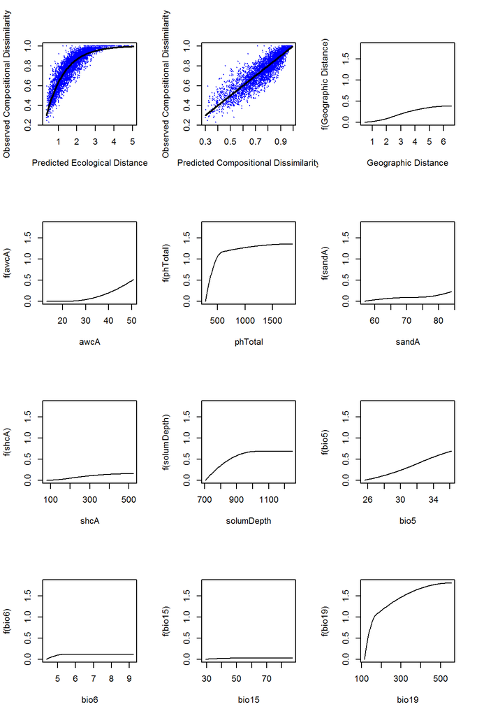

```r
plot(gdm.1, plot.layout=c(4,3))
```

To allow easy customization of I-spline plots, the `isplineExtract` function will extract the plotted values for each I-spline.

```r
gdm.1.splineDat <- isplineExtract(gdm.1)
str(gdm.1.splineDat)
```

```
## List of 2
##  $ x: num [1:200, 1:11] 0.452 0.483 0.513 0.544 0.574 ...
##   ..- attr(*, "dimnames")=List of 2
##   .. ..$ : NULL
##   .. ..$ : chr [1:11] "Geographic" "awcA" "phTotal" "sandA" ...
##  $ y: num [1:200, 1:11] 0 0.00045 0.00095 0.0015 0.0021 ...
##   ..- attr(*, "dimnames")=List of 2
##   .. ..$ : NULL
##   .. ..$ : chr [1:11] "Geographic" "awcA" "phTotal" "sandA" ...
```

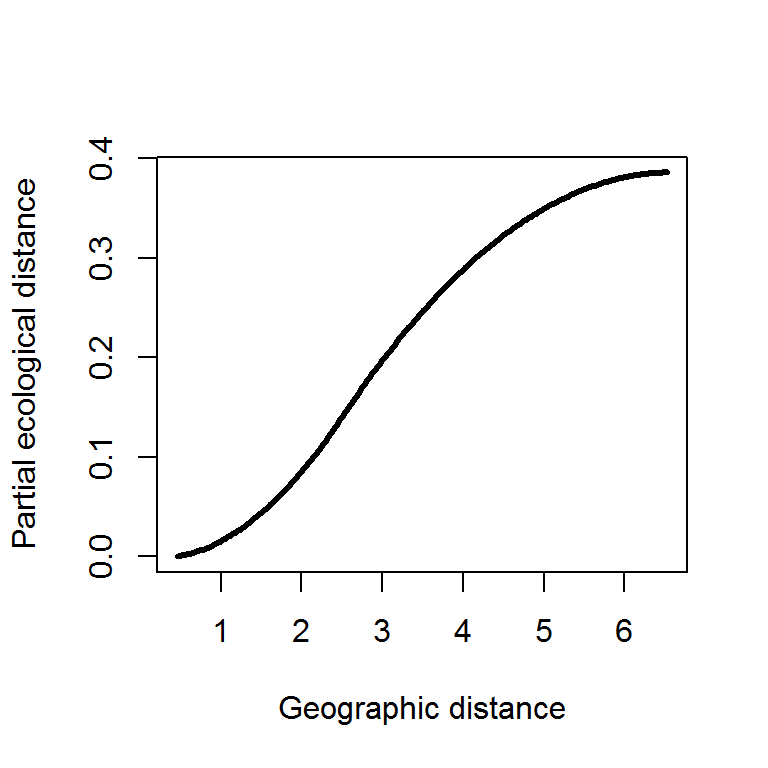

```r
plot(gdm.1.splineDat$x[,"Geographic"], gdm.1.splineDat$y[,"Geographic"], lwd=3,
     type="l", xlab="Geographic distance", ylab="Partial ecological distance")
```

## **gdm** predictions

The I-splines provide an indication of how species composition (or other biological measure) changes along each environmental gradient. Beyond these insights, a fitted model also can be used to (i) predict biological dissimilarity between site pairs in space or between times using the `predict` function and (ii) transform the predictor variables from their arbitrary environmental scales to a common biological importance scale using the `transform` function.

The examples show predictions between site pairs and through time, and transformation of both tabular and raster data. Fr the raster example, the transformed layers are used to map spatial patterns of biodiversity.

## Predicting biological distances between sites

The `predict` function requires a site-pair table in the same format as that used to fit the model. For demonstration purposes, we use the same table as that used to fit the model, though predictions to new sites (or times) can be made as well assuming the same set of environmental/spatial predictors are available at those locations (or times).

```r
gdm.1.pred <- predict(gdm.1, gdmTab)
head(gdm.1.pred)
```

```
## [1] 0.4720423 0.7133571 0.8710175 0.8534788 0.9777208 0.3996694
```

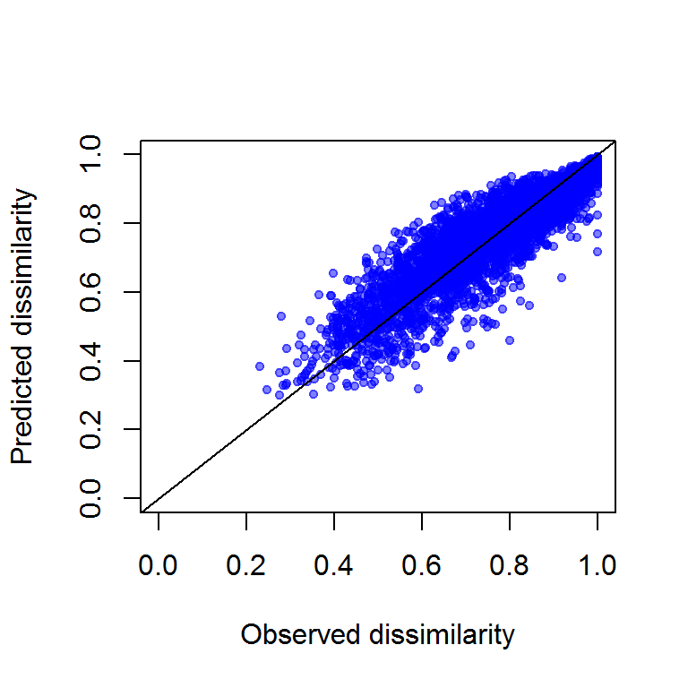

```r
plot(gdmTab$distance, gdm.1.pred, xlab="Observed dissimilarity",
     ylab="Predicted dissimilarity", xlim=c(0,1), ylim=c(0,1), pch=20, col=rgb(0,0,1,0.5))
lines(c(-1,2), c(-1,2))
```

## Predicting biological change through time

The `predict` function can be used to make predictions across time (Blois et al. 2013), for example, under climate change scenarios to estimate the magnitude of expected change in biological composition in response to environmental change (Fitzpatrick et al. 2011). In this case, rasters must be provided for two time periods of interest.

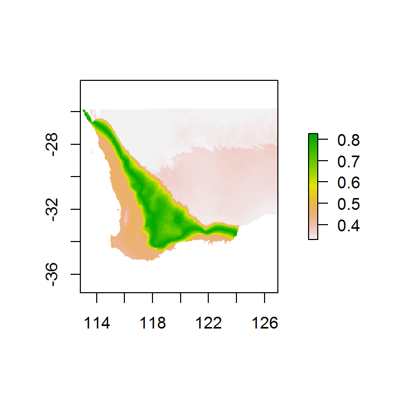

```r
# fit a new gdm using a table with climate data only (to match rasters)
gdm.rast <- gdm(gdmTab.rast, geo=T)

# make some fake climate change data
futRasts <- envRast
##reduce winter precipitation by 25% & increase temps
futRasts[[3]] <- futRasts[[3]]*0.75
futRasts[[4]] <- futRasts[[4]]+2
futRasts[[5]] <- futRasts[[5]]+3

timePred <- predict(gdm.rast, envRast, time=T, predRasts=futRasts)
plot(timePred)
```

## Transforming predictors and visualizing biological patterns

### Transforming from environmental space to biological space

Predictor data to be transformed can be in one of two formats: a data frame with columns in the order of: X, Y, var1, var2, …, varN, or a raster stack or brick with one layer per predictor. Beyond the x- and y-columns in the data frame, the order of the predictor data (columns for tabular data, layers for rasters) must be the same as that in the site-pair table used in model fitting. If the model was fit *without* using geographical distance, then the x- and y-columns of the data frame should not be included in the predictor data. If the model was fit *with* geographical distance and raster data are provided to the `transform` function, there is no need to provide x- or y-raster layers as these will be generated automatically . However, the character names of the x- and y-coordinates (e.g., “Lat” and “Long”) used to fit the model need to be provided.

```r
# reordering environmental data to create table for transformation
envTrans <- envTab[, c(13,12,2:11)] # same order as gdmTab
envTrans[1:3,]
```

```
##       Long       Lat    awcA  phTotal   sandA    shcA solumDepth     bio5
## 1 118.7573 -32.99425 14.4725 546.1800 71.3250 178.865   875.1725 31.43824
## 2 118.3495 -32.04285 16.2575 470.9950 68.8975 105.840   928.4925 33.14412
## 3 117.8260 -31.99067 23.1375 459.7425 71.4700  88.355   892.2275 32.84000
##       bio6    bio15 bio18    bio19
## 1 5.058823 40.38235     0 132.6471
## 2 4.852941 48.20588     0 140.2941
## 3 4.817143 53.88571    43 145.0571
```

```r
tabTrans <- gdm.transform(gdm.1, envTrans)
# now scaled to biological importance
tabTrans[1:3,]
```

```
##           Long       Lat         awcA   phTotal      sandA         shcA
## [1,] 0.2226638 0.1036539 0.0000000000 1.1437240 0.09098455 0.0349996799
## [2,] 0.1985913 0.1598227 0.0000000000 0.9902375 0.08618790 0.0025608921
## [3,] 0.1676795 0.1629031 0.0005822033 0.9560643 0.09114130 0.0003213945
##      solumDepth      bio5       bio6      bio15 bio18     bio19
## [1,]  0.5407158 0.3488653 0.10210250 0.01846392     0 0.5102596
## [2,]  0.6269481 0.4892084 0.08073046 0.02528373     0 0.6754013
## [3,]  0.5726173 0.4650542 0.07620206 0.02711470     0 0.7637484
```

```r
# transform climate rasters & plot pattern
rastTrans <- gdm.transform(gdm.rast, envRast)
#plot(rastTrans)
```

### Visualizing multi-dimensional biological patterns

Pairwise site biological distances are difficult to visualize. However, if the `transform` function is applied to rasters, the resulting multi-dimensional biological space can be mapped to reveal biological patterns in geographic space. Alternatively, a biplot can be used to depict where sites fall relative to each other in biological space and therefore how sites differ in predicted biological composition. In either case, the multi-dimensional biological space can be most effectively visualized by taking a PCA to reduce dimensionality and assigning the first three components to an RGB color palette.

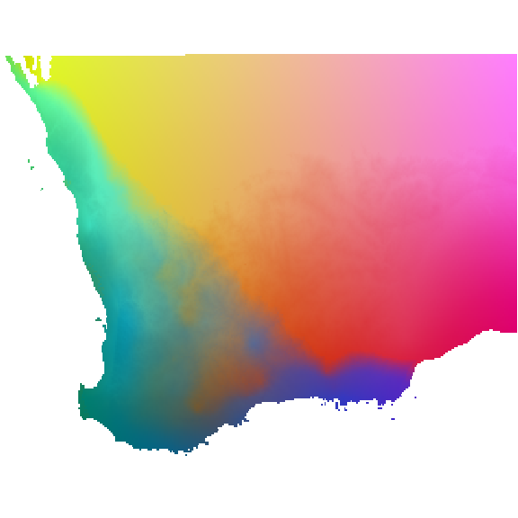

```r
rastDat <- na.omit(getValues(rastTrans))
#rastDat <- sampleRandom(rastTrans, 50000) # can use if rasters are large
pcaSamp <- prcomp(rastDat)

# note the use of the 'index' argument
pcaRast <- predict(rastTrans, pcaSamp, index=1:3)

# scale rasters
pcaRast[[1]] <- (pcaRast[[1]]-pcaRast[[1]]@data@min) /
  (pcaRast[[1]]@data@max-pcaRast[[1]]@data@min)*255
pcaRast[[2]] <- (pcaRast[[2]]-pcaRast[[2]]@data@min) /
  (pcaRast[[2]]@data@max-pcaRast[[2]]@data@min)*255
pcaRast[[3]] <- (pcaRast[[3]]-pcaRast[[3]]@data@min) /
  (pcaRast[[3]]@data@max-pcaRast[[3]]@data@min)*255

plotRGB(pcaRast, r=1, g=2, b=3)
```

References

Blois, JL, Williams JW, Fitzpatrick MC, Jackson ST, and S Ferrier. 2013. “Space Can Substitute for Time in Predicting Climate-Change Effects on Biodiversity.” *Proceedings of the National Academy of Sciences* 110: 9374–79.

Ferrier, S, Manion G, Elith J, and K Richardson. 2007. “Using Generalized Dissimilarity Modelling to Analyse and Predict Patterns of Beta Diversity in Regional Biodiversity Assessment.” *Diversity & Distributions* 13: 252–64.

Fitzpatrick, MC, and SR Keller. 2015. “Ecological Genomics Meets Community-Level Modeling of Biodiversity: mapping the Genomic Landscape of Current and Future Environmental Adaptation.” *Ecology Letters* 18: 1–16.

Fitzpatrick, MC, Sanders NJ, Ferrier S, Longino JT, Weiser MD, and RR Dunn. 2011. “Forecasting the Future of Biodiversity: a Test of Single- and Multi-Species Models for Ants in North America.” *Ecography* 34: 836–47.

Fitzpatrick, MC, Sanders NJ, Normand S, Svenning JC, Ferrier S, Gove AD, and RR Dunn. 2013. “Environmental and Historical Imprints on Beta Diversity: insights from Variation in Rates of Species Turnover Along Gradients.” *Proceedings of the Royal Society of London B: Biological Sciences* 280 (1768).

Jones, MM, Ferrier S, Condit R, Manion G, Aguilar S, and R Pérez. 2013. “Strong Congruence in Tree and Fern Community Turnover in Response to Soils and Climate in Central Panama.” *Journal of Ecology* 101: 506–16.

Rosauer, DF, Ferrier S, Williams KJ, Manion G, Keogh JS, and SW Laffan. 2014. “Phylogenetic Generalised Dissimilarity Modelling: a New Approach to Analysing and Predicting Spatial Turnover in the Phylogenetic Composition of Communities.” *Ecography* 37: 21–32.

Thomassen, HA, Cheviron ZA, Freedman AH, Harrigan RJ, Wayne RK, and TB Smith. 2010. “Spatial Modelling and Landscape-Level Approaches for Visualizing Intra-Specific Variation.” *Molecular Ecology* 19: 3532–48.